# Análise de gastos de deputados

Gabriel Morais Lúcio de Araújo

25 de outubro de 2017

```r
dadosCEAP <- read.csv("~/Github/analiseDeDados/dados/dadosCEAP.csv")
```

### 1. Quais os partidos que mais fazem uso da CEAP? Quais os partidos que menos fazem uso? Mesmas perguntas conisderando valores em R$.

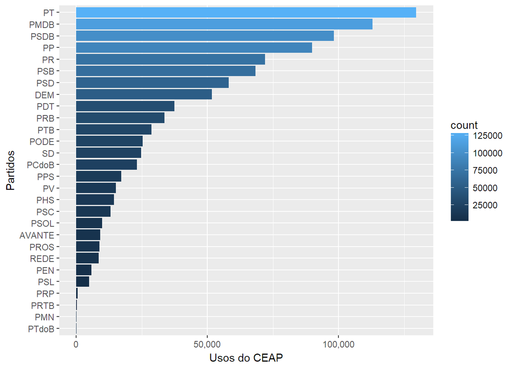

```r
dados.cont.usos <- dadosCEAP %>%
  group_by(sgPartido) %>%
  summarise(count = n()) %>%
  arrange(desc(count)) %>%
  na.omit()

dados.cont.usos.4 <- dados.cont.usos %>%
  slice(1:4)

ggplot(dados.cont.usos, aes(x = reorder(sgPartido, count), y = count, fill = count)) +
  geom_bar(stat="identity") +
  scale_y_continuous(labels = scales::comma) +
  coord_flip() +
  labs('Total de usos do CEAP', x = 'Partidos', y = 'Usos do CEAP')
```

Temos o PT e PMDB como partidos que mais utilizam do CEAP, o PT com 129587 usos e o PMDB com 112875 usos. Já para os partidos que menos utilizam do CEAP temos o PTdoB e o PMN, com 50 e 61 usos, respectivamente.

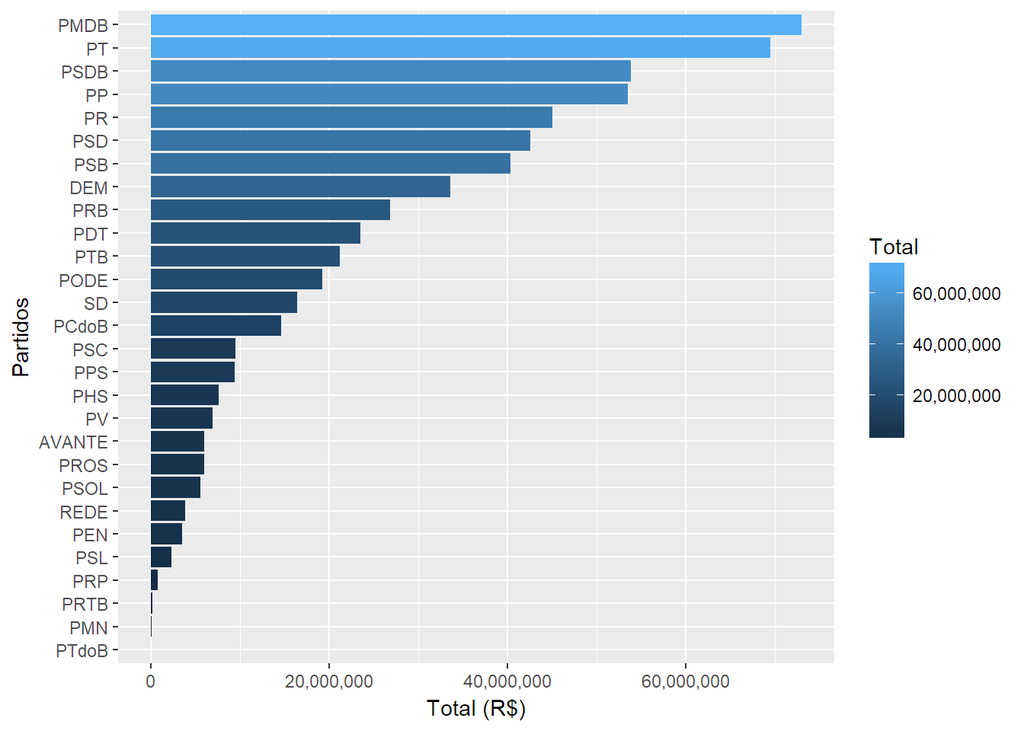

```r
dados.sum.gastos <- dadosCEAP %>%
  group_by(sgPartido) %>%
  summarise(Total = sum(valorDocumento)) %>%
  arrange(desc(Total)) %>%
  na.omit()

total.gasto <- sum(dados.sum.gastos$Total)

ggplot(dados.sum.gastos, aes(x = reorder(sgPartido, Total), y = Total, fill = Total)) +
  geom_bar(stat="identity") +
  scale_y_continuous(labels = scales::comma) +
  scale_fill_continuous(labels = scales::comma) +
  coord_flip() +
  labs('Total gasto em R$', x = 'Partidos', y = 'Total (R$)')
```

Analisando o total utilizado (em R$) do CEAP é observado que agora o PMDB passa a frente do PT nos partidos que mais gastam. O PMDB gastou R$72.977.077,78 e o PT gastou R$69.451.237,72. Já para os partidos que menos gastam a situação se mantem igual a da analise anterior, os PTdoB e PMN são os partidos que menos gastam, com R$15.596,45 e R$88.527,78.

### 2. Quais os tipos de despesa mais comuns no uso da CEAP? Mesma pergunta considerando valores em R$.

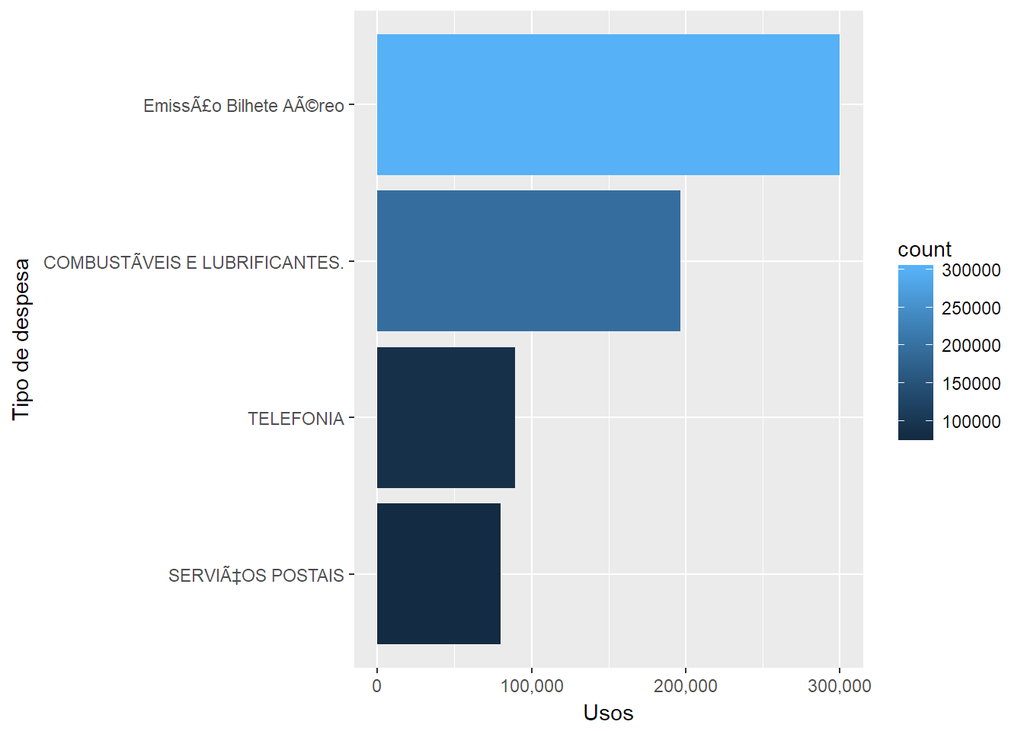

```r
dados.cont.despesas <- dadosCEAP %>%
  group_by(tipoDespesa) %>%
  summarise(count = n()) %>%
  arrange(desc(count)) %>%
  na.omit()

dados.cont.despesas.4 <- dados.cont.despesas %>% slice(1:4)

ggplot(dados.cont.despesas.4, aes(x = reorder(tipoDespesa, count), y = count, fill = count)) +
  geom_bar(stat="identity") +
  scale_y_continuous(labels = scales::comma) +
  coord_flip() +
  labs("Despesas mais comuns", x = 'Tipo de despesa', y = 'Usos')
```

Emissão de bilhetes áereos e Combustivéis e lubrificantes são as despesas mais comuns no uso da CEAP, com 300185 e 196858 usos, respectivamente.

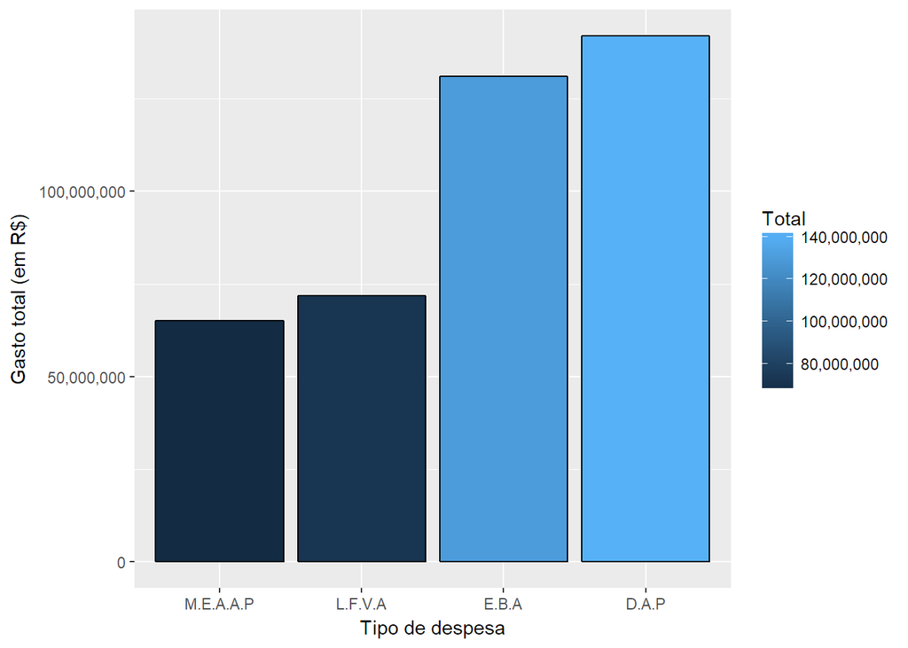

```r
dados.sum.despesas <- dadosCEAP %>%
  group_by(tipoDespesa) %>%
  summarise(total = sum(valorDocumento)) %>%
  arrange(desc(total)) %>%
  na.omit()

dados.sum.despesas.4 <- dados.sum.despesas %>% slice(1:4)

ggplot(dados.sum.despesas.4, aes(x = reorder(tipoDespesa, total), y = total)) +
  geom_bar(aes(fill = dados.sum.despesas.4$total), stat="identity", colour="black") +
  scale_x_discrete(labels=c("M.E.A.A.P", "L.F.V.A", "E.B.A", "D.A.P")) +
  scale_y_continuous(labels = scales::comma) +
  scale_fill_continuous(labels = scales::comma) +
  labs("Despesas com maior gasto do CEAP", x = 'Tipo de despesa', y = 'Gasto total (em R$)', fill = 'Total')
```

##### Os nomes das despesas foram abreviados no gráfico para melhor visualização

| Abreviação | Significado |
| --- | --- |
| D.A.P | Divulgação da Atividade Parlamentar |
| E.B.A | Emissão de Bilhete Aéreo |
| L.F.V.A | Locação ou Fretamento de Veículos Automotivos |
| M.E.A.A.P | Manutenção de Escritório de Apoio à Atividade Parlamentar |

Consigerando o valor gasto em R$ agora temos Divulgação de Atividade Parlamentar (R$141.982.694) como despesa com maior gasto, além disso pode-se notar que a despesa com combustivéis não está entre as 4 despesas que mais gastam, mesmo sendo a segunda despesa com mais usos.

### 3. Levando em conta o estado pelo qual o deputado se elegeu, quais os estados que mais fazem uso da CEAP? Quais os que menos fazem uso? Mesmas perguntas considerando gastos em R$. Por que você acha isso?

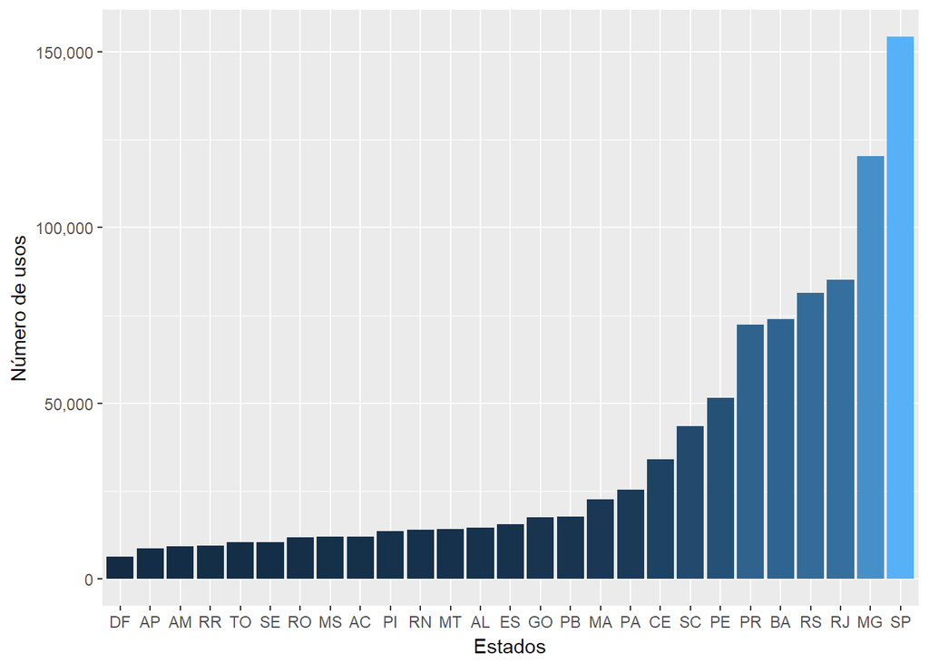

```r
dados.cont.estado <- dadosCEAP %>%
  group_by(sgUF) %>%
  summarise(count = n()) %>%
  arrange(desc(count)) %>%
  na.omit()

ggplot(dados.cont.estado, aes(x = reorder(sgUF, count), y = count)) +
  geom_bar(stat = "identity", aes(fill = dados.cont.estado$count)) +
  scale_y_continuous(labels = scales::comma) +
  guides(fill = FALSE) +
  labs("Estados que mais utilizam do CEAP", x = "Estados", y = "Número de usos")
```

São Paulo, Minas Gerais e Rio de Janeiro são os estados que mais utilizam do CEAP, com 154289, 120389 e 85180 usos, respectivamente. Amazonas, Amapa e Distrito Federal são os estados que menos utilizam do CEAP, com 9138, 8561 e 6179 usos, respectivamente.

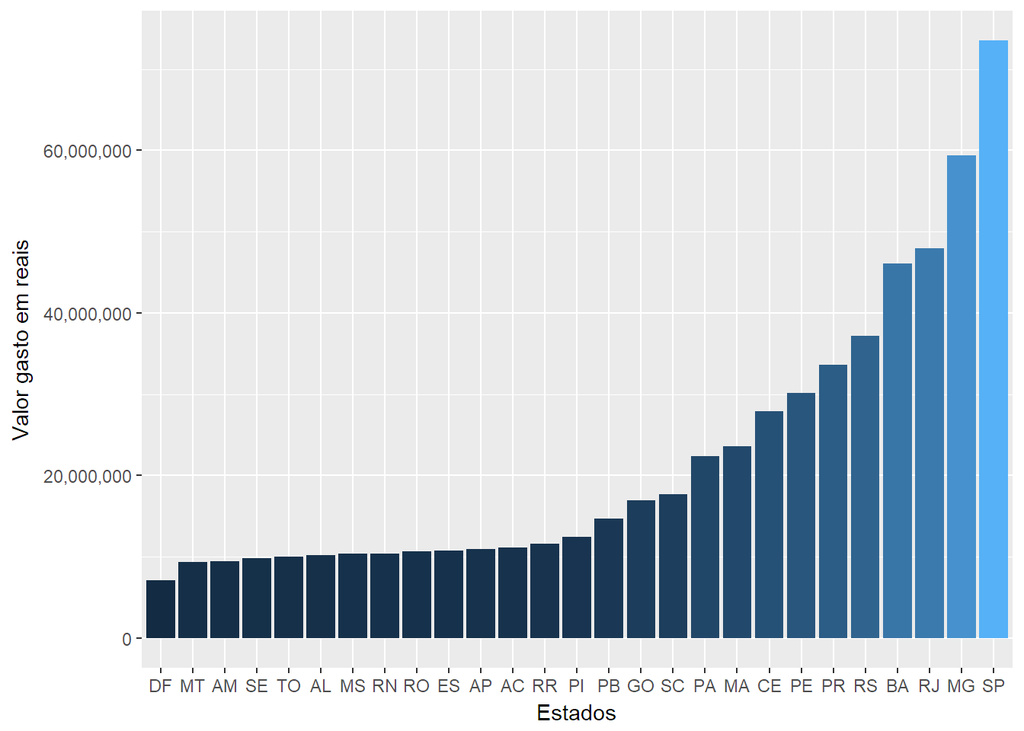

```r
dados.sum.estado <- dadosCEAP %>%
  group_by(sgUF) %>%
  summarise(total = sum(valorDocumento)) %>%
  arrange(desc(total)) %>%
  na.omit()

ggplot(dados.sum.estado, aes(x = reorder(sgUF, total), y = total)) +
  geom_bar(stat = "identity", aes(fill = dados.sum.estado$total)) +
  scale_y_continuous(labels = scales::comma) +
  scale_fill_continuous(labels = scales::comma) +
  guides(fill = FALSE) +
  labs("Estados que mais gastam em R$", x = "Estados", y = "Valor gasto em reais")
```

Agora analisando o valor gasto em reais podemos ver que os 3 estados que mais utilizam do CEAP são os que mais gastam também, porém os 3 estados que menos gastam não são os mesmos, Mato Grosso tomou o lugar 26° do Amapá (que em número de usos estava nessa posição) que subiu para a posição 17 em gasto.

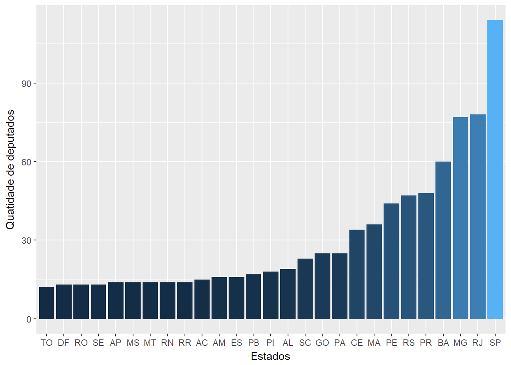

```r
dados.cont.deputado <- dadosCEAP %>%
  group_by(sgUF) %>%
  distinct(nomeParlamentar) %>%
  summarise(nDeputados = n()) %>%
  na.omit()

ggplot(dados.cont.deputado, aes(x = reorder(sgUF, nDeputados), y = nDeputados)) +
  geom_bar(stat = "identity", aes(fill = dados.cont.deputado$nDeputados)) +
  guides(fill = FALSE) +
  labs("Número de deputados por estado", x = "Estados", y = "Quatidade de deputados")
```

Fazendo mais uma analise é possível observar que os estados que mais utilizam e gastam da CEAP são também os estados que mais possuem deputados, o mesmo não pode ser dito para os estados que menos gastam/utilizam, mas é válido dizer que muitos dos estados que menos gastam estão entre os estados com menor número de deputados.

### 4. Quais os parlamentares que mais gastam com CEAP e quais os que menos gastam?

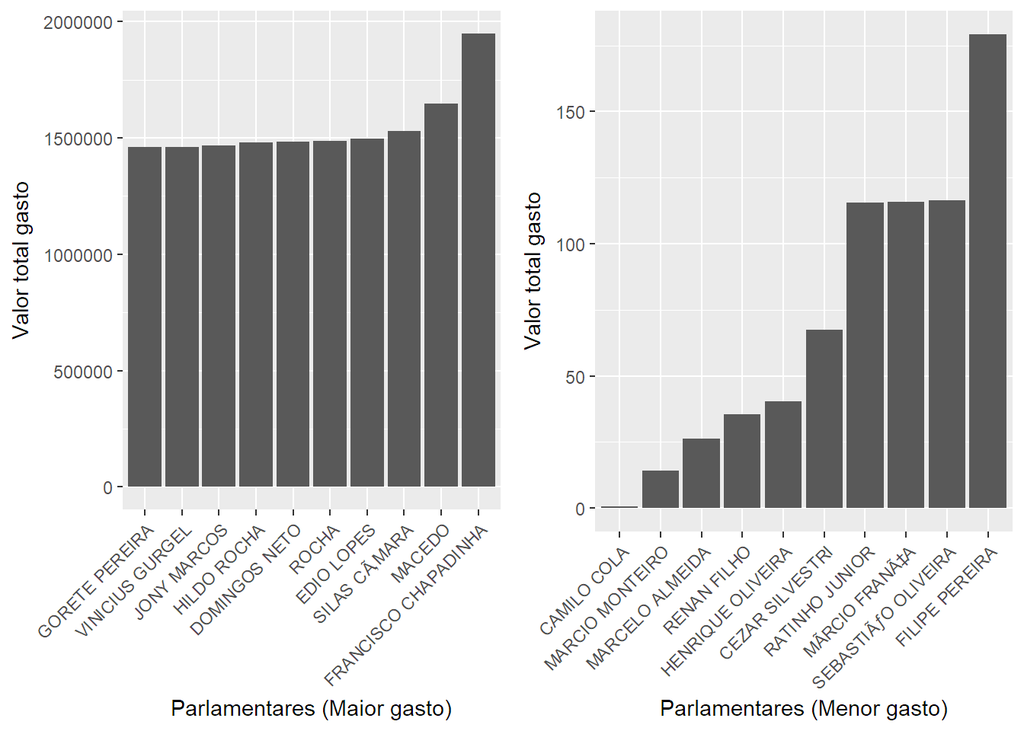

```r
dados.sum.gastoDeputado <- dadosCEAP %>%
  group_by(nomeParlamentar) %>%
  summarise(total = sum(valorDocumento)) %>%
  arrange(desc(total)) %>%
  na.omit()

dados.sum.maisGasto <- dados.sum.gastoDeputado %>%
  top_n(10)

dados.sum.menosGasto <- dados.sum.gastoDeputado %>%
  top_n(-14) %>% top_n(10)

maisGasta <- ggplot(dados.sum.maisGasto, aes(x = reorder(nomeParlamentar, total), y = total)) +
  geom_bar(stat = "identity") +
  theme(axis.text.x=element_text(angle=45,hjust=1)) +
  labs("Parlamentares que mais gastam do CEAP", x = "Parlamentares (Maior gasto)", y = "Valor total gasto")

menosGasta <- ggplot(dados.sum.menosGasto, aes(x = reorder(nomeParlamentar, total), y = total)) +
  geom_bar(stat = "identity") +
  theme(axis.text.x=element_text(angle=45,hjust=1)) +
  labs("Parlamentares que menos gastam do CEAP", x = "Parlamentares (Menor gasto)", y = "Valor total gasto")

grid.arrange(maisGasta, menosGasta, ncol=2)
```

### 5. Existe correlação entre a quantidade de gastos no exterior e o valor restituído da CEAP?

```r
dados.exterior <- dadosCEAP %>%
  filter(tipoDocumento == 2)
```